# P9_vantyghem_notebook

[figure not shown]

**Sommaire**

Import des librairies  
I. Préparation des données  
II. Identification des principaux pays acteurs de la filière volaille  
III. Réalisation du clustering CAH et Kmeans  
IV. Analyse en Composantes Principales  
V. Conclusion

**Import des librairies**

```python
import matplotlib.pyplot as plt
import pandas as pd
import numpy as np
from sklearn import decomposition
from sklearn import preprocessing
from sklearn.cluster import KMeans
from sklearn import metrics
from scipy.cluster.hierarchy import dendrogram, linkage, fcluster
import seaborn as sns
import geopandas
from functions import *
# les fonctions sont issues du cours https://openclassrooms.com/fr/courses/4525281-realisez-une-analyse-exploratoire-de-donnees
#seules quelques fonctionnalités ont été modifiées (ajout des centroïdes sur les graphiques par exemple)
```

# I. Préparation des données

## 1.1 Fichier disponibilité alimentaire pour les années 2017 2019

Note :

Afin de calculer de nouvelles variables représentant des taux d'évolution entre 2017 et 2019, des données supplémentaires ont été recherchées sur le site de la FAO.

Le site permettant de réaliser un export de données personnalisé (choix des pays années, des produits, des éléments à exporter...), un export unique visant à sélectionner, pour l'ensemble des pays :

- les années souhaitées (2017 et 2019),
- les éléments étudiés (disponibilité intérieure, import, export, production, disponibilité par personne et par jour)
- les produits étudiés (éléments relatifs à la consommation de viande et à la population de chaque pays)

L'export a été réalisé en anglais et non en français afin de régler le problème d'encodage des accents.

L'étude est donc réalisée à partir du Dataframe food_balances_2017_2019 directement et non le CSV DisponibilitéAlimentaire_2017 fourni par OpenClassrooms

### A - Présentation du fichier : variables, dimension, valeurs nulles, doublons

```python
dispo_alimentaire = pd.read_csv("food_balances_17_2019.csv")
```

```python
dispo_alimentaire.head()
```

|  | Domain | Area | Element | Item | Year | Unit | Value |
| --- | --- | --- | --- | --- | --- | --- | --- |
| 0 | Food Balances (2010-) | Afghanistan | Total Population - Both sexes | Population | 2017 | 1000 persons | 36296 |
| 1 | Food Balances (2010-) | Afghanistan | Total Population - Both sexes | Population | 2019 | 1000 persons | 38042 |
| 2 | Food Balances (2010-) | Afghanistan | Domestic supply quantity | Population | 2017 | 1000 tonnes | 0 |
| 3 | Food Balances (2010-) | Afghanistan | Domestic supply quantity | Population | 2019 | 1000 tonnes | 0 |
| 4 | Food Balances (2010-) | Afghanistan | Production | Poultry Meat | 2017 | 1000 tonnes | 28 |

```python
dispo_alimentaire.shape
```

```
(2419, 7)
```

```python
dispo_alimentaire.dtypes
```

```
Domain     object
Area       object
Element    object
Item       object
Year        int64
Unit       object
Value       int64
dtype: object
```

```python
dispo_alimentaire.describe(include = 'all')
```

|  | Domain | Area | Element | Item | Year | Unit | Value |
| --- | --- | --- | --- | --- | --- | --- | --- |
| count | 2419 | 2419 | 2419 | 2419 | 2419.000000 | 2419 | 2.419000e+03 |
| unique | 1 | 179 | 6 | 2 | NaN | 3 | NaN |
| top | Food Balances (2010-) | Republic of Korea | Domestic supply quantity | Poultry Meat | NaN | 1000 tonnes | NaN |
| freq | 2419 | 14 | 716 | 1703 | NaN | 1703 | NaN |
| mean | NaN | NaN | NaN | NaN | 2017.997933 | NaN | 7.737845e+03 |
| std | NaN | NaN | NaN | NaN | 1.000205 | NaN | 7.307915e+04 |
| min | NaN | NaN | NaN | NaN | 2017.000000 | NaN | 0.000000e+00 |
| 25% | NaN | NaN | NaN | NaN | 2017.000000 | NaN | 2.000000e+00 |
| 50% | NaN | NaN | NaN | NaN | 2017.000000 | NaN | 4.500000e+01 |
| 75% | NaN | NaN | NaN | NaN | 2019.000000 | NaN | 2.580000e+02 |
| max | NaN | NaN | NaN | NaN | 2019.000000 | NaN | 1.465634e+06 |

```python
dispo_alimentaire.isnull().mean()
```

```
Domain     0.0
Area       0.0
Element    0.0
Item       0.0
Year       0.0
Unit       0.0
Value      0.0
dtype: float64
```

```python
doublons_dispo = dispo_alimentaire.duplicated()
```

```python
doublons_dispo.value_counts()
```

```
False    2419
dtype: int64
```

Les données ne présentent pas de valeur nulle ou de doublon.

### B - Nettoyage des données

```python
#conversion de la variable année vers le type str
dispo_alimentaire["Year"] = dispo_alimentaire["Year"].astype(str)
```

```python
#visualisation des valeurs uniques des variables et identification des modifications à apporter
for column in dispo_alimentaire.columns[0:-1] :
    print(f'- Unique values column {column} : {dispo_alimentaire[column].unique()}')
```

```
- Unique values column Domain : ['Food Balances (2010-)']
- Unique values column Area : ['Afghanistan' 'Albania' 'Algeria' 'Angola' 'Antigua and Barbuda'
 'Argentina' 'Armenia' 'Australia' 'Austria' 'Azerbaijan' 'Bahamas'
 'Bangladesh' 'Barbados' 'Belarus' 'Belgium' 'Belize' 'Benin'
 'Bolivia (Plurinational State of)' 'Bosnia and Herzegovina' 'Botswana'
 'Brazil' 'Bulgaria' 'Burkina Faso' 'Burundi' 'Cabo Verde' 'Cambodia'
 'Cameroon' 'Canada' 'Central African Republic' 'Chad' 'Chile' 'China'
 'China, Hong Kong SAR' 'China, Macao SAR' 'China, mainland'
 'China, Taiwan Province of' 'Colombia' 'Comoros' 'Congo' 'Costa Rica'
 "C?te d'Ivoire" 'Croatia' 'Cuba' 'Cyprus' 'Czechia'
 "Democratic People's Republic of Korea"
 'Democratic Republic of the Congo' 'Denmark' 'Djibouti' 'Dominica'
 'Dominican Republic' 'Ecuador' 'Egypt' 'El Salvador' 'Estonia' 'Eswatini'
 'Ethiopia' 'Fiji' 'Finland' 'France' 'French Polynesia' 'Gabon' 'Gambia'
 'Georgia' 'Germany' 'Ghana' 'Greece' 'Grenada' 'Guatemala' 'Guinea'
 'Guinea-Bissau' 'Guyana' 'Haiti' 'Honduras' 'Hungary' 'Iceland' 'India'
 'Indonesia' 'Iran (Islamic Republic of)' 'Iraq' 'Ireland' 'Israel'
 'Italy' 'Jamaica' 'Japan' 'Jordan' 'Kazakhstan' 'Kenya' 'Kiribati'
 'Kuwait' 'Kyrgyzstan' "Lao People's Democratic Republic" 'Latvia'
 'Lebanon' 'Lesotho' 'Liberia' 'Libya' 'Lithuania' 'Luxembourg'
 'Madagascar' 'Malawi' 'Malaysia' 'Maldives' 'Mali' 'Malta' 'Mauritania'
 'Mauritius' 'Mexico' 'Mongolia' 'Montenegro' 'Morocco' 'Mozambique'
 'Myanmar' 'Namibia' 'Nepal' 'Netherlands' 'New Caledonia' 'New Zealand'
 'Nicaragua' 'Niger' 'Nigeria' 'North Macedonia' 'Norway' 'Oman'
 'Pakistan' 'Panama' 'Papua New Guinea' 'Paraguay' 'Peru' 'Philippines'
 'Poland' 'Portugal' 'Republic of Korea' 'Republic of Moldova' 'Romania'
 'Russian Federation' 'Rwanda' 'Saint Kitts and Nevis' 'Saint Lucia'
 'Saint Vincent and the Grenadines' 'Samoa' 'Sao Tome and Principe'
 'Saudi Arabia' 'Senegal' 'Serbia' 'Seychelles' 'Sierra Leone' 'Slovakia'
 'Slovenia' 'Solomon Islands' 'South Africa' 'Spain' 'Sri Lanka' 'Sudan'
 'Suriname' 'Sweden' 'Switzerland' 'Syrian Arab Republic' 'Tajikistan'
 'Thailand' 'Timor-Leste' 'Togo' 'Trinidad and Tobago' 'Tunisia' 'Turkey'
 'Turkmenistan' 'Uganda' 'Ukraine'
 'United Kingdom of Great Britain and Northern Ireland'
 'United Republic of Tanzania' 'United States of America' 'Uruguay'
 'Uzbekistan' 'Vanuatu' 'Venezuela (Bolivarian Republic of)' 'Viet Nam'
 'Yemen' 'Zambia' 'Zimbabwe']
- Unique values column Element : ['Total Population - Both sexes' 'Domestic supply quantity' 'Production'
 'Import Quantity' 'Food supply (kcal/capita/day)' 'Export Quantity']
- Unique values column Item : ['Population' 'Poultry Meat']
- Unique values column Year : ['2017' '2019']
- Unique values column Unit : ['1000 persons' '1000 tonnes' 'kcal/capita/day']
```

```python
# changement d'unités : les valeurs sont initialement exprimées pour 1000 personnes ou 1000 tonnes
dispo_alimentaire.loc[(dispo_alimentaire['Unit'].isin(["1000 persons", "1000 tonnes"])),"Value"] = dispo_alimentaire.loc[(dispo_alimentaire['Unit'].isin(["1000 persons", "1000 tonnes"])),"Value"] * 1000
```

```python
#modification des labels "unit"
dispo_alimentaire.loc[(dispo_alimentaire['Element'].isin(['Domestic supply quantity', 'Production','Import Quantity', 'Export Quantity'])), "Unit"] =  "(tonnes)"
dispo_alimentaire.loc[(dispo_alimentaire['Element'].isin(['Total Population - Both sexes', 'Food supply (kcal/capita/day)'])), "Unit"] =  ""
```

```python
#modification "Côte d'Ivoire"
dispo_alimentaire.replace("C?te d'Ivoire", "Côte d'Ivoire", inplace= True)
```

```python
#suppression des lignes relatives à la zone "China mainland" pour éviter la redondance avec "China"
china_mainland_index = dispo_alimentaire[dispo_alimentaire["Area"] == "China, mainland"].index
```

```python
dispo_alimentaire.drop(china_mainland_index, inplace= True)
```

```python
# concaténation des variables "element, item et year"
dispo_alimentaire["Element-item-year"] = dispo_alimentaire["Element"] + " " + dispo_alimentaire["Item"] + " " + dispo_alimentaire["Unit"] + " " + dispo_alimentaire["Year"]
```

```python
# suppression des colonnes non utiles
dispo_alimentaire.drop(columns = ["Domain", "Element", "Item", "Year", "Unit"], inplace=True)
```

```python
# suppression des lignes non utiles : les éléments Domestic supply quantity Population (tonnes) 2017 et Domestic supply quantity Population (tonnes) 2019 ne sont pas pertinents et sont donc filtrés
dispo_alimentaire = dispo_alimentaire[(dispo_alimentaire["Element-item-year"] != "Domestic supply quantity Population (tonnes) 2017") & (dispo_alimentaire["Element-item-year"] != "Domestic supply quantity Population (tonnes) 2019")]
```

### C - Création de la table pivot et calcul de nouvelles variables

```python
# création de la table pivot
dispo_alimentaire = dispo_alimentaire.pivot(index='Area', columns='Element-item-year', values='Value')
```

```python
dispo_alimentaire.head()
```

| Element-item-year Area | Domestic supply quantity Poultry Meat (tonnes) 2017 | Domestic supply quantity Poultry Meat (tonnes) 2019 | Export Quantity Poultry Meat (tonnes) 2017 | Export Quantity Poultry Meat (tonnes) 2019 | Food supply (kcal/capita/day) Poultry Meat 2017 | Food supply (kcal/capita/day) Poultry Meat 2019 | Import Quantity Poultry Meat (tonnes) 2017 | Import Quantity Poultry Meat (tonnes) 2019 | Production Poultry Meat (tonnes) 2017 | Production Poultry Meat (tonnes) 2019 | Total Population - Both sexes Population 2017 | Total Population - Both sexes Population 2019 |
| --- | --- | --- | --- | --- | --- | --- | --- | --- | --- | --- | --- | --- |
| Afghanistan | 64000.0 | 67000.0 | NaN | NaN | 6.0 | 6.0 | 29000.0 | 44000.0 | 28000.0 | 28000.0 | 36296000.0 | 38042000.0 |
| Albania | 33000.0 | 34000.0 | 0.0 | 0.0 | 59.0 | 61.0 | 20000.0 | 22000.0 | 13000.0 | 12000.0 | 2884000.0 | 2881000.0 |
| Algeria | 286000.0 | 287000.0 | 0.0 | 1000.0 | 24.0 | 23.0 | 2000.0 | 0.0 | 284000.0 | 291000.0 | 41389000.0 | 43053000.0 |
| Angola | 318000.0 | 327000.0 | 0.0 | 0.0 | 36.0 | 34.0 | 277000.0 | 278000.0 | 40000.0 | 49000.0 | 29817000.0 | 31825000.0 |
| Antigua and Barbuda | 6000.0 | 7000.0 | 0.0 | 0.0 | 247.0 | 265.0 | 7000.0 | 7000.0 | 0.0 | 0.0 | 95000.0 | 97000.0 |

```python
dispo_alimentaire.shape
```

```
(178, 12)
```

calcul de variables concernant les évolutions de la balance commerciale par pays :

- evolution des imports (part des imports mondiaux) entre 2017 et 2019
- evolution des exports (part des exports mondiaux) entre 2017 et 2019

```python
#calcul des variables part des imports et des exports mondiaux
def percentage_calcul (df, column, new_name) :
    df[new_name] = df[column]/df[column].sum()
```

```python
percentage_calcul(dispo_alimentaire, "Export Quantity Poultry Meat (tonnes) 2017", "Poultry meat export part 2017")
percentage_calcul(dispo_alimentaire, "Export Quantity Poultry Meat (tonnes) 2019", "Poultry meat export part 2019")
percentage_calcul(dispo_alimentaire, "Import Quantity Poultry Meat (tonnes) 2017", "Poultry meat import part 2017")
percentage_calcul(dispo_alimentaire, "Import Quantity Poultry Meat (tonnes) 2019", "Poultry meat import part 2019")
```

```python
dispo_alimentaire[["Poultry meat export part 2017", "Poultry meat import part 2017"]].isnull().mean()
```

```
Element-item-year
Poultry meat export part 2017    0.213483
Poultry meat import part 2017    0.005618
dtype: float64
```

```python
# remplacement des NaN par 0
dispo_alimentaire["Poultry meat export part 2017"].replace(0, np.nan, inplace= True)
dispo_alimentaire["Poultry meat import part 2017"].replace(0, np.nan, inplace=True)
dispo_alimentaire["Poultry meat import part 2019"].replace(0, np.nan, inplace=True)
dispo_alimentaire["Poultry meat import part 2019"].replace(0, np.nan, inplace=True)
```

```python
dispo_alimentaire["Import share evolution 17-2019"] = dispo_alimentaire["Poultry meat import part 2019"]-dispo_alimentaire["Poultry meat import part 2017"]
dispo_alimentaire["Export share evolution 17-2019"] = dispo_alimentaire["Poultry meat export part 2019"]-dispo_alimentaire["Poultry meat export part 2017"]
```

```python
#suppression des variables relatives  :
# aux consommations 2017 (on conserve uniquement les valeurs 2019 et les taux d'évolution 2017 2019)
cols_to_delete = [col for col in dispo_alimentaire.columns if "2017" in col or "part" in col]
```

```python
dispo_alimentaire.drop(columns = cols_to_delete, inplace = True)
```

## 1.2 Fichier sécurité alimentaire pour les années 2017 2019

Ajout d'indicateurs :

- économiques
- politiques

utilisation des données "sécurité alimentaire 2017 et 2019 " issues du site de la FAO

```python
securite_alimentaire = pd.read_csv("food_security_indicators_2017_19.csv", sep = ";")
```

```python
securite_alimentaire.head()
```

|  | Area | Item | Year | Value |
| --- | --- | --- | --- | --- |
| 0 | Afghanistan | Gross dosmestic product per capita | 2017 | 2058.40 |
| 1 | Afghanistan | Gross dosmestic product per capita | 2019 | 2065.00 |
| 2 | Afghanistan | Political stability and absence of violence | 2017 | -2.80 |
| 3 | Afghanistan | Political stability and absence of violence | 2019 | -2.65 |
| 4 | Albania | Gross dosmestic product per capita | 2017 | 12771.00 |

```python
#suppression des lignes relatives à la zone china mainland pour éviter la redondance avec China
china_mainland_index_2 = securite_alimentaire[securite_alimentaire["Area"] == "China, mainland"].index
securite_alimentaire.drop(china_mainland_index_2, inplace= True)
```

```python
#conversion de la variable année vers le type str
securite_alimentaire["Year"] = securite_alimentaire["Year"].astype(str)
```

```python
#concaténation des variables item et year
securite_alimentaire["Item-Year"] = securite_alimentaire["Item"] + " " + securite_alimentaire["Year"]
```

```python
securite_alimentaire.head()
```

|  | Area | Item | Year | Value | Item-Year |
| --- | --- | --- | --- | --- | --- |
| 0 | Afghanistan | Gross dosmestic product per capita | 2017 | 2058.40 | Gross dosmestic product per capita 2017 |
| 1 | Afghanistan | Gross dosmestic product per capita | 2019 | 2065.00 | Gross dosmestic product per capita 2019 |
| 2 | Afghanistan | Political stability and absence of violence | 2017 | -2.80 | Political stability and absence of violence 2017 |
| 3 | Afghanistan | Political stability and absence of violence | 2019 | -2.65 | Political stability and absence of violence 2019 |
| 4 | Albania | Gross dosmestic product per capita | 2017 | 12771.00 | Gross dosmestic product per capita 2017 |

```python
# création de la table pivot
securite_alimentaire = securite_alimentaire.pivot(index = "Area", columns = "Item-Year", values = "Value")
```

```python
#suppression des variables relatives aux données 2017 (on conserve uniquement les valeurs 2019 et les taux d'évolution 2017 2019)
securite_alimentaire.drop(columns = ["Gross dosmestic product per capita 2017", "Political stability and absence of violence 2017"], inplace = True)
```

## 1.3 Fusion des dataframes

Fusion des données disponibilité alimentaire et sécurité alimentaire : left join afin de conserver l'ensemble des 178 zones du df "disponibilité alimentaire"

```python
df_final = pd.merge(dispo_alimentaire, securite_alimentaire, on ="Area", how = "left")
```

```python
df_final.columns
```

```
Index(['Domestic supply quantity Poultry Meat (tonnes) 2019',
       'Export Quantity Poultry Meat (tonnes) 2019',
       'Food supply (kcal/capita/day) Poultry Meat  2019',
       'Import Quantity Poultry Meat (tonnes) 2019',
       'Production Poultry Meat (tonnes) 2019',
       'Total Population - Both sexes Population  2019',
       'Import share evolution 17-2019', 'Export share evolution 17-2019',
       'Gross dosmestic product per capita 2019',
       'Political stability and absence of violence 2019'],
      dtype='object')
```

```python
#vérification du nombre de valeurs nulles suite à la fusion
df_final.isnull().mean()
```

```
Domestic supply quantity Poultry Meat (tonnes) 2019    0.000000
Export Quantity Poultry Meat (tonnes) 2019             0.241573
Food supply (kcal/capita/day) Poultry Meat  2019       0.000000
Import Quantity Poultry Meat (tonnes) 2019             0.005618
Production Poultry Meat (tonnes) 2019                  0.011236
Total Population - Both sexes Population  2019         0.000000
Import share evolution 17-2019                         0.151685
Export share evolution 17-2019                         0.533708
Gross dosmestic product per capita 2019                0.050562
Political stability and absence of violence 2019       0.022472
dtype: float64
```

```python
#il y a plus de 24 % et 53% de valeurs nulles concernant les taux d'évolution export et les quantités d'export de volaille : on considère que ce sont des pays qui n'exportent pas de viande de volaille
#affichage des distribution des variables ayant des valeurs nulles
is_null_after_join = df_final.isnull().mean()>0
```

```python
col_null_after_join = df_final.isnull().mean()[is_null_after_join].index
```

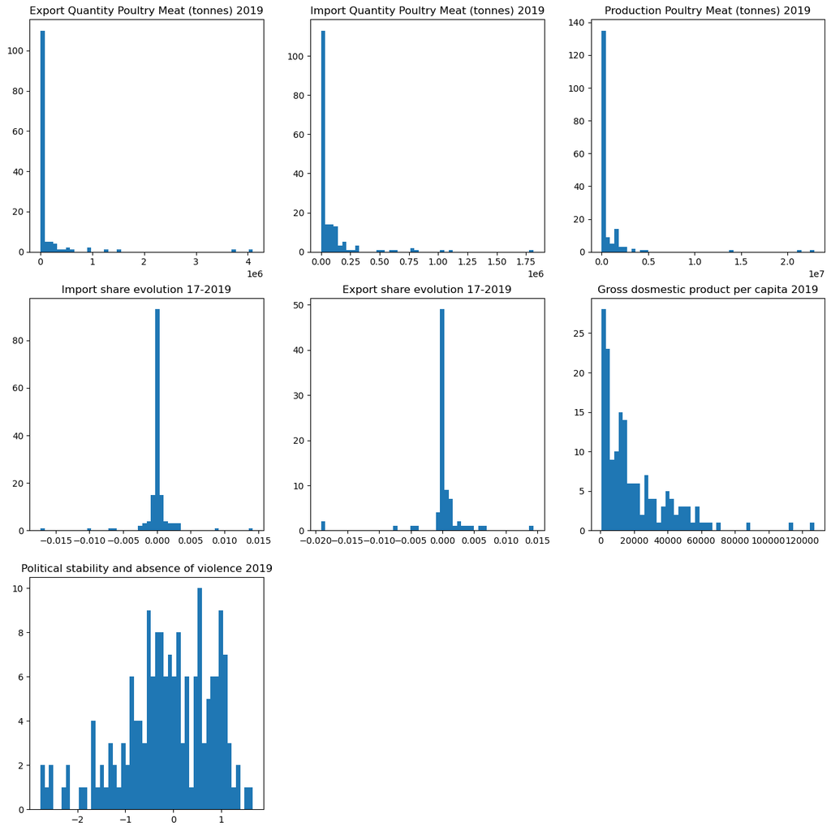

```python
fig = plt.figure(figsize=(16, 16))
i=1
for col in col_null_after_join :
    ax = fig.add_subplot(3,3,i)
    ax.hist(df_final[col], bins = 50)
    ax.set_title(col)
    i+=1
plt.show()
```

```python
#remplacement des valeurs nulles par 0
for col in col_null_after_join :
    df_final[col].fillna(0, inplace = True)
```

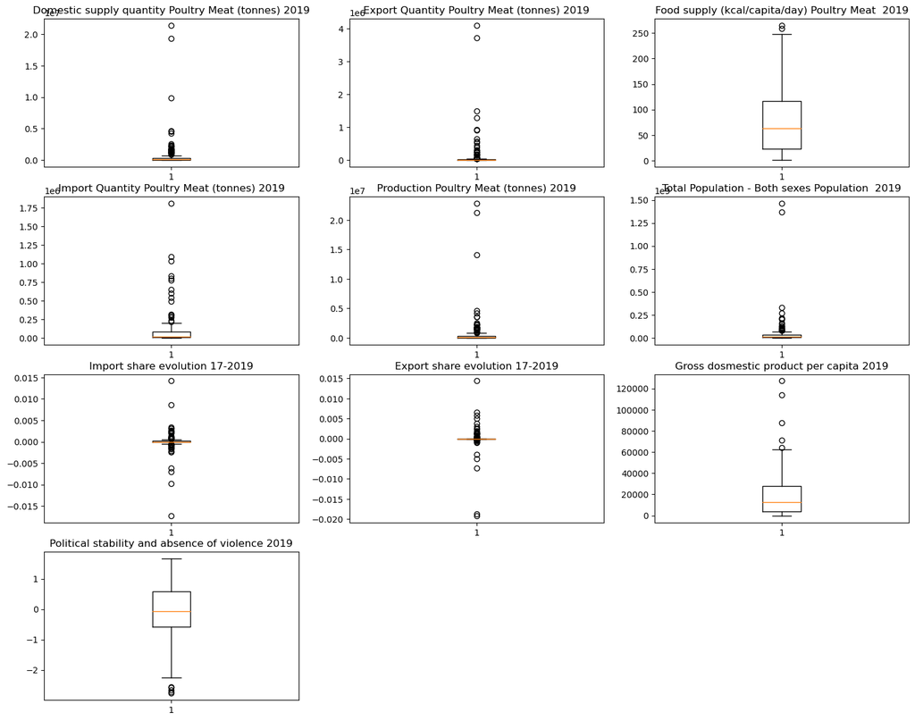

```python
#visualisation des dispertion des variables : la majorité des variables présentent des outliers
fig = plt.figure(figsize=(18, 18))
i=1
for col in df_final.columns :
    ax = fig.add_subplot(5,3,i)
    ax.boxplot(df_final[col])
    ax.set_title(col)
    i+=1
plt.show()
```

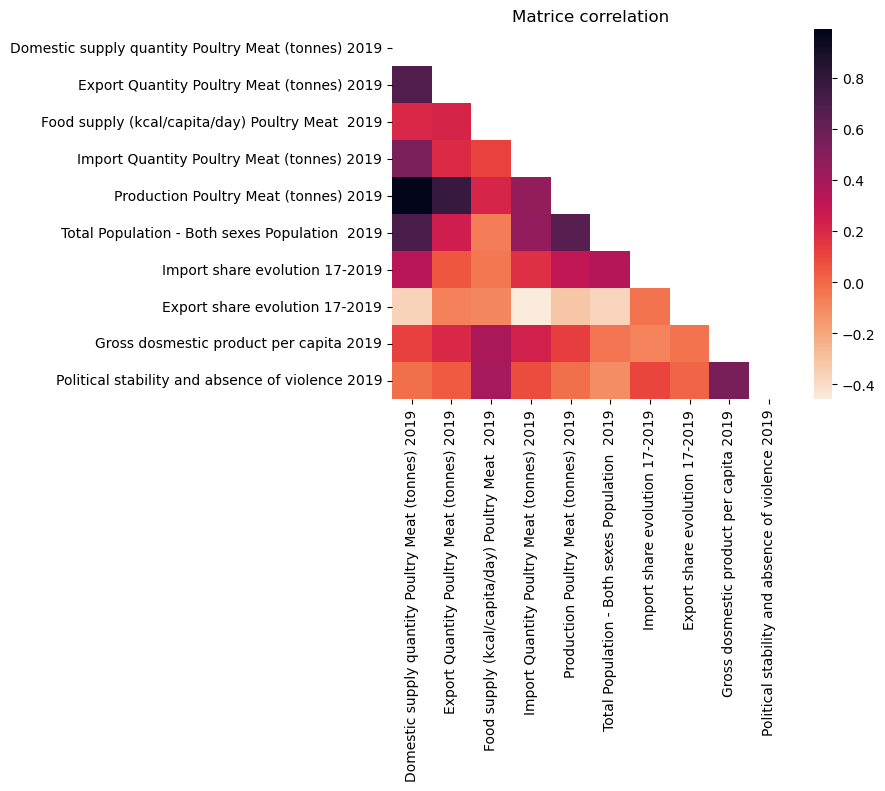

```python
# générer un masque pour le triangle des corrélations entre variables
mask = np.triu(np.ones_like(df_final.corr(), dtype=bool))
#affichage de la corrélation entre variables
corr_matrice = plt.figure()
cmap = sns.cm.rocket_r
sns.heatmap(df_final.corr(), mask = mask, cmap =cmap)
plt.title("Matrice correlation")
plt.show()
```

On constate quer certaines variables sont fortement corrélées :

- **disponibilité intérieure**, corrélée positivement avec : export, import, production, population, anticorrelé avec l'évolution des exports (parts du marché international)
- **export (quantités)**, corrélée positivement avec : production, disponibilité intérieure
- **imports (quantités)**, corrélée positivement avec : population, production, disponibilité intérieure anticorrelé avec l'évolution des exports (parts du marché international)
- **production**, corrélée positivement avec : population, disponibilité intérieure, export (quantité), imports(quantité), anticorrelé avec l'évolution des exports (parts du marché international)
- **évolution des imports (parts du marché international)**, corrélée positivement avec : population, disponibilité intérieure, production
- **évolution des exports (parts du marché international)** anticorrélé avec : taille de la population, production, disponibilité intérieure, imports (quantité)
- **population**, corrélée positivement avec : disponibilité intérieure (quantité) production (quantité)
- **disponibilité alimentaire (kcal/pers/jour), PIB par habitant, stabilité politique** sont corrélées positivement

# II. Identification des principaux pays acteurs de la filière volaille

### 2.1 Principaux pays producteurs (en tonnes)

```python
dispo_alimentaire.sort_values(by = "Production Poultry Meat (tonnes) 2019", ascending = False).head(20)["Production Poultry Meat (tonnes) 2019"]
```

```
Area
United States of America                                22858000.0
China                                                   21195000.0
Brazil                                                  14137000.0
Russian Federation                                       4606000.0
India                                                    4232000.0
Indonesia                                                3539000.0
Mexico                                                   3515000.0
Poland                                                   2558000.0
Japan                                                    2298000.0
Iran (Islamic Republic of)                               2292000.0
Argentina                                                2248000.0
Turkey                                                   2202000.0
United Kingdom of Great Britain and Northern Ireland     1902000.0
Myanmar                                                  1817000.0
South Africa                                             1816000.0
Thailand                                                 1775000.0
Peru                                                     1763000.0
Malaysia                                                 1717000.0
Colombia                                                 1693000.0
France                                                   1660000.0
Name: Production Poultry Meat (tonnes) 2019, dtype: float64
```

### 2.2 Principaux pays exportateurs (en tonnes)

```python
dispo_alimentaire.sort_values(by = "Export Quantity Poultry Meat (tonnes) 2019", ascending = False).head(20)["Export Quantity Poultry Meat (tonnes) 2019"]
```

```
Area
Brazil                                                  4099000.0
United States of America                                3725000.0
Netherlands                                             1493000.0
Poland                                                  1294000.0
Thailand                                                 921000.0
China                                                    903000.0
Germany                                                  644000.0
Belgium                                                  565000.0
Turkey                                                   522000.0
France                                                   429000.0
United Kingdom of Great Britain and Northern Ireland     383000.0
China, Hong Kong SAR                                     310000.0
Ukraine                                                  296000.0
Hungary                                                  259000.0
Spain                                                    247000.0
Argentina                                                234000.0
Russian Federation                                       223000.0
Italy                                                    180000.0
Belarus                                                  177000.0
Chile                                                    173000.0
Name: Export Quantity Poultry Meat (tonnes) 2019, dtype: float64
```

### 2.3 Principaux pays importateurs (en tonnes)

```python
dispo_alimentaire.sort_values(by = "Import Quantity Poultry Meat (tonnes) 2019", ascending = False).head(20)["Import Quantity Poultry Meat (tonnes) 2019"]
```

```
Area
China                                                   1814000.0
Japan                                                   1094000.0
Mexico                                                  1033000.0
Germany                                                  831000.0
United Kingdom of Great Britain and Northern Ireland     798000.0
China, Hong Kong SAR                                     773000.0
Saudi Arabia                                             650000.0
Netherlands                                              602000.0
France                                                   541000.0
South Africa                                             488000.0
Belgium                                                  320000.0
Philippines                                              306000.0
Cuba                                                     294000.0
Angola                                                   278000.0
Russian Federation                                       232000.0
China, Taiwan Province of                                215000.0
Viet Nam                                                 203000.0
Spain                                                    188000.0
Republic of Korea                                        185000.0
Kazakhstan                                               182000.0
Name: Import Quantity Poultry Meat (tonnes) 2019, dtype: float64
```

### 2.4 Pays ayant gagné le plus de points en parts d'imports internationaux entre 2017 et 2019

```python
dispo_alimentaire.sort_values(by = "Import share evolution 17-2019", ascending = False).head(20)["Import share evolution 17-2019"]
```

```
Area
China                               0.014213
Viet Nam                            0.008595
Yemen                               0.003444
Philippines                         0.003112
China, Taiwan Province of           0.003069
Republic of Korea                   0.002738
Turkey                              0.002524
Slovakia                            0.002426
Mexico                              0.002187
Colombia                            0.002155
Poland                              0.001946
France                              0.001339
Democratic Republic of the Congo    0.001118
Libya                               0.001079
Hungary                             0.001016
Afghanistan                         0.000878
Kuwait                              0.000826
Uzbekistan                          0.000789
Azerbaijan                          0.000696
Dominican Republic                  0.000672
Name: Import share evolution 17-2019, dtype: float64
```

### 2.5 Pays ayant gagné le plus de points en parts d'exports internationaux entre 2017 et 2019

```python
dispo_alimentaire.sort_values(by = "Export share evolution 17-2019", ascending = False).head(20)["Export share evolution 17-2019"]
```

```
Area
Poland                                                  0.014367
Thailand                                                0.006627
Russian Federation                                      0.005759
Turkey                                                  0.004956
Netherlands                                             0.003834
Chile                                                   0.003060
Hungary                                                 0.002613
Republic of Korea                                       0.002429
Spain                                                   0.001857
Viet Nam                                                0.001564
Argentina                                               0.001426
Belarus                                                 0.001327
Romania                                                 0.001285
United Kingdom of Great Britain and Northern Ireland    0.001241
United States of America                                0.001220
Ukraine                                                 0.001200
Denmark                                                 0.000789
Iran (Islamic Republic of)                              0.000533
Austria                                                 0.000474
Zambia                                                  0.000432
Name: Export share evolution 17-2019, dtype: float64
```

### 2.6 Pays ayant perdu le plus de points en parts d'imports internationaux entre 2017 et 2019

```python
dispo_alimentaire.sort_values(by = "Import share evolution 17-2019").head(20)["Import share evolution 17-2019"]
```

```
Area
Iraq                   -0.017262
China, Hong Kong SAR   -0.009732
Saudi Arabia           -0.007002
Egypt                  -0.006197
South Africa           -0.002436
Ukraine                -0.002354
Germany                -0.002042
Tajikistan             -0.001665
Cuba                   -0.001615
Spain                  -0.001380
Netherlands            -0.001355
Romania                -0.001223
Chile                  -0.000981
Oman                   -0.000882
Liberia                -0.000818
Belarus                -0.000712
Syrian Arab Republic   -0.000670
Cambodia               -0.000571
Canada                 -0.000480
Australia              -0.000458
Name: Import share evolution 17-2019, dtype: float64
```

### 2.7 Pays ayant perdu le plus de points en parts d'exports internationaux entre 2017 et 2019

```python
dispo_alimentaire.sort_values(by = "Export share evolution 17-2019").head(20)["Export share evolution 17-2019"]
```

```
Area
China, Hong Kong SAR        -0.019158
China                       -0.018815
Brazil                      -0.007336
Belgium                     -0.005013
France                      -0.003963
Portugal                    -0.000924
Canada                      -0.000835
South Africa                -0.000819
Saudi Arabia                -0.000493
Oman                        -0.000380
Lithuania                   -0.000334
Czechia                     -0.000328
New Zealand                 -0.000273
Suriname                    -0.000271
Mexico                      -0.000217
Germany                     -0.000206
Italy                       -0.000190
China, Taiwan Province of   -0.000163
Lebanon                     -0.000163
Bulgaria                    -0.000115
Name: Export share evolution 17-2019, dtype: float64
```

### Principaux pays acteurs de la filière volaille

- Les **Etats Unis, le Brésil et la Chine** sont les trois principaux **producteurs** mondiaux.
- Les **Etats Unis et le Brésil**, sont des les principaux **exportateurs** mondiaux, à l'inverse de la **Chine**, qui est le principal **importateur** mondial.
  - Les **Pays Bas et la Pologne** se distinguent également comme principaux pays **exportateurs**, derrière le Brésil et les Etats Unis.
  - La **Japon et le Mexique** ont eux des quantité d'**import** très importantes, et se situent derrière la Chine.
- Les pays ayant le plus **progressé** en termes d'**exports** sont la **Pologne, la Thailande et la Russie**, qui sont déjà des acteurs importants sur le marché de l'export de volail (respectivmeent 4ème 5ème et 17ème en quantité d'exports mondiaux). A l'inverse, les pays ayant le plus **diminué** leurs parts d'**exports** internationaux sont **Hong Kong, la Chine, le Brésil**.
- Concernant les évolutions de parts de marché entre 2017 et 2019, les pays ayant le plus **progressé** en termes d'**imports** sont la **Chine, le Vietnam (17ème pays importateur en quantité) et le Yemen**. A l'inverse, les pays ayant le plus **diminué** leurs parts d'**imports** internationaux sont l'**Iraq, Hong Kong et l'Arabie Saoudite** (7ème pays importateur en quantité).

Concernant la **France**, elle se classe **20ème pays producteur, 9ème pays importateur, 10ème pays exportateur, 12ème pays ayant gagné le plus de parts de marché en imports entre 2017 et 2019 et 5ème pays ayant le plus perdu de parts de marché en exports entre 2017 et 2019**.

Les géants du marché mondial de la volaille sont donc les Etats Unis, le Brésil, la Chine. On constate qu'il existe des dynamiques et stratégies en termes de balance commerciale au sein de chaque pays : la France par exemple, semble faire reposer sa disponibilité alimentaire en volaille de plus en plus sur l'import et recule en parts d'exports.

Certains pays anciennement structurellement importateurs comme l'Arabie Saoudite ou Hong Kong, semblent faire reculer leurs imports et ne seront donc probablement pas les pays à cibler en priorité. D'autres pays, déjà fortement importateurs font progresser leurs imports tels que la Chine, le Mexique le Vietnam, la Corée, tandis que certains pays émergent en tant qu'importateurs (Philippines, Taiwan, Yemen).

Des pays tels que la Pologne, la Thaïlande, ou la Russie renforcent leurs position en tant que principaux pays exportateurs, tandis que certains pays émergent en tant qu'exportateur, telle que la Roumanie.

# III. Réalisation du clustering CAH et Kmeans

## 3.1 Préparation des données

```python
# préparation des données pour clustering et ACP
X = df_final.values
names = df_final.index
features = df_final.columns
```

```python
#centrage et réduction des valeurs
X_scaled = preprocessing.StandardScaler().fit_transform(X)
```

## 3.2 Dendrogramme

```python
#générer la matrice des liens, utilisation de la méthode de Ward
Z = linkage(X_scaled, method='ward', metric='euclidean')
```

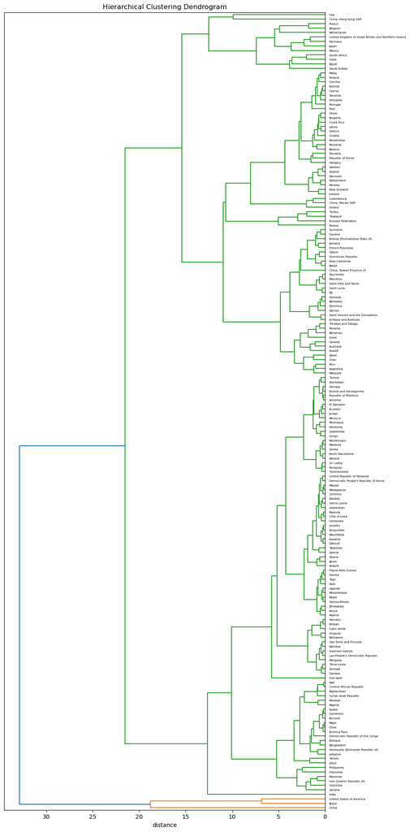

```python
# affichage du dendrogramme
fig = plt.figure(figsize = (15,15))
plot_dendrogram(Z, names)
```

## 3.3 Calcul des coefficients de silhouette et DB scores

- Coefficient de silhouette
- Davies–Bouldin (DB) score pour un nombre de cluster entre 3 et 12, pour la méthode CAH et le Kmeans

```python
#calcul des indicateurs pour la méthode CAH
db_CAH, slc_CAH = {}, {}
for i in range (3,12) :
    clusters_CAH = fcluster(Z, i, criterion='maxclust')
    slc_CAH[i] = metrics.silhouette_score(X_scaled, clusters_CAH)
    db_CAH[i] = metrics.davies_bouldin_score(X_scaled, clusters_CAH)
```

```python
#calcul des indicateurs pour la méthode Kmeans
inertia, db_km, slc_km = {}, {}, {}
for i in range (3,12) :
    kmeans = KMeans(n_clusters=i, random_state=0).fit(X_scaled)
    clusters_km = kmeans.labels_
    inertia[i] = kmeans.inertia_
    slc_km[i] = metrics.silhouette_score(X_scaled, clusters_km)
    db_km[i] = metrics.davies_bouldin_score(X_scaled, clusters_km)
```

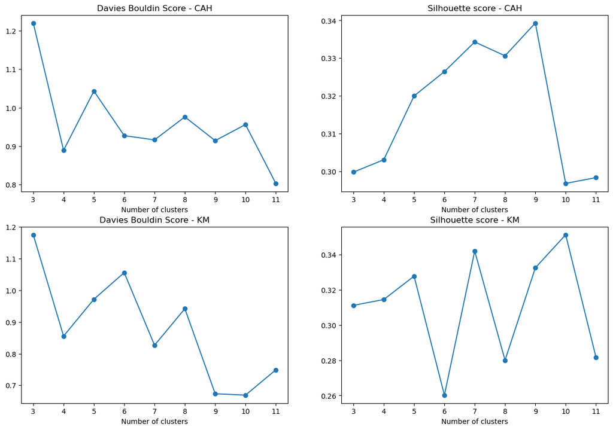

```python
fig = plt.figure(figsize=(15,10))
ax1 = fig.add_subplot(2,2,1)
ax2 = fig.add_subplot(2,2,2)
ax3 = fig.add_subplot(2,2,3)
ax4 = fig.add_subplot(2,2,4)

ax1.plot(db_CAH.keys(), list(db_CAH.values()), marker='o')
ax1.set_title("Davies Bouldin Score - CAH")
ax1.set_xlabel("Number of clusters")
ax2.plot(slc_CAH.keys(), list(slc_CAH.values()), marker='o' )
ax2.set_title("Silhouette score - CAH")
ax2.set_xlabel("Number of clusters")
ax3.plot(db_km.keys(), list(db_km.values()), marker='o')
ax3.set_title("Davies Bouldin Score - KM")
ax3.set_xlabel("Number of clusters")
ax4.plot(slc_km.keys(), list(slc_km.values()), marker='o')
ax4.set_title("Silhouette score - KM")
ax4.set_xlabel("Number of clusters")
plt.show()
```

- Les indicateurs CAH donnent de meilleurs scores pour un nombre de cluster égale à 7 ou 9
- Les ndicateurs KM donnent de meilleurs scores pour un nombre de cluster égale à 7 ou 10

On fixe le nombre de clusters à 7

## 3.4 Clustering CAH

```python
#définition des clusters par la méthode CAH
clusters_CAH = fcluster(Z, 7, criterion='maxclust')
```

```python
#les numéro de cluster sont ajoutés au df
df_final["cluster CAH"] = clusters_CAH
```

## 3.5 Clustering Kmeans

```python
#définition des clusters par la méthode Kmeans
#nombre de clusters souhaités
n_clust = 7

# clustering par K-means, ici pour récupérer les coordonnées des centroides calculés,
#pour initialisation du kmeans avec init dans un second temps
km_get_centroïdes = KMeans(n_clusters=n_clust, random_state=0)
km_get_centroïdes.fit(X_scaled)

# récupération des coordonnées des centroïdes pour utilisation dans init
centroids_after_kmeans_get_centroides = km_get_centroïdes.cluster_centers_
```

```python
centroids_after_kmeans_get_centroides
```

```
array([[-1.30572971e-01, -8.23737889e-02,  8.12826288e-01,
        -1.32407963e-01, -1.24631909e-01, -2.02654841e-01,
         3.80133770e-02,  1.64327900e-01,  6.86226303e-01,
         7.81560680e-01],
       [-1.83392902e-01, -1.86076408e-01, -6.36912448e-01,
        -2.68929791e-01, -1.76904193e-01, -8.68399777e-02,
         7.94965045e-02,  6.49767148e-02, -5.85802189e-01,
        -5.36713871e-01],
       [ 8.82388342e+00,  1.77002263e+00, -1.29794485e-01,
         7.94088052e+00,  7.81901017e+00,  9.23158187e+00,
         6.44576203e+00, -7.30177459e+00, -1.39000760e-01,
         1.19256637e-01],
       [ 5.93011597e+00,  8.43636815e+00,  2.15867799e+00,
        -1.24909702e-01,  6.78779868e+00,  1.47276640e+00,
        -2.32131345e-02, -1.18680247e+00,  9.40812738e-01,
        -1.55051798e-02],
       [ 6.21839396e-01,  7.22738897e-01,  2.62961395e-01,
         3.12708523e+00,  4.68559790e-01,  2.26638147e-01,
        -1.72571884e-01, -7.49009066e-03,  9.76660038e-01,
         4.85808777e-01],
       [-1.57419723e-03,  2.79256934e-02,  7.81428910e-01,
         1.93225089e+00, -1.66268548e-01, -1.16646340e-01,
        -5.14816638e+00, -2.54214886e+00,  9.57270750e-01,
        -1.05227275e+00],
       [ 1.50523205e+00, -2.17252850e-01, -1.05143186e+00,
        -4.19887172e-01,  1.33432416e+00,  8.58770954e+00,
        -4.89062727e-03,  4.15461019e-02, -6.05407249e-01,
        -6.35409535e-01]])
```

```python
#création d'un np array avec les coordonnées des centroïdes
centroids_after_kmeans_get_centroides = np.array([[-1.30572971e-01, -8.23737889e-02,  8.12826288e-01,
        -1.32407963e-01, -1.24631909e-01, -2.02654841e-01,
         3.80133770e-02,  1.64327900e-01,  6.86226303e-01,
         7.81560680e-01],
       [-1.83392902e-01, -1.86076408e-01, -6.36912448e-01,
        -2.68929791e-01, -1.76904193e-01, -8.68399777e-02,
         7.94965045e-02,  6.49767148e-02, -5.85802189e-01,
        -5.36713871e-01],
       [ 8.82388342e+00,  1.77002263e+00, -1.29794485e-01,
         7.94088052e+00,  7.81901017e+00,  9.23158187e+00,
         6.44576203e+00, -7.30177459e+00, -1.39000760e-01,
         1.19256637e-01],
       [ 5.93011597e+00,  8.43636815e+00,  2.15867799e+00,
        -1.24909702e-01,  6.78779868e+00,  1.47276640e+00,
        -2.32131345e-02, -1.18680247e+00,  9.40812738e-01,
        -1.55051798e-02],
       [ 6.21839396e-01,  7.22738897e-01,  2.62961395e-01,
         3.12708523e+00,  4.68559790e-01,  2.26638147e-01,
        -1.72571884e-01, -7.49009066e-03,  9.76660038e-01,
         4.85808777e-01],
       [-1.57419723e-03,  2.79256934e-02,  7.81428910e-01,
         1.93225089e+00, -1.66268548e-01, -1.16646340e-01,
        -5.14816638e+00, -2.54214886e+00,  9.57270750e-01,
        -1.05227275e+00],
       [ 1.50523205e+00, -2.17252850e-01, -1.05143186e+00,
        -4.19887172e-01,  1.33432416e+00,  8.58770954e+00,
        -4.89062727e-03,  4.15461019e-02, -6.05407249e-01,
        -6.35409535e-01]])
```

```python
# clustering par K-means avec initialisation des centroïdes aux coordonnées précedemment calculées
km = KMeans(n_clusters=n_clust, init = centroids_after_kmeans_get_centroides, max_iter= 500)
km.fit(X_scaled)

# récupération des clusters attribués à chaque individu et des coordonnées des centroïdes
clusters_km = km.labels_
centroids_after_kmeans = km.cluster_centers_
```

```python
#les numéro de cluster sont ajoutés au df
df_final["cluster kmeans"] = clusters_km
```

## 3.6 Etude de la concordance entre les clusters issus de la CAH et du Kmeans

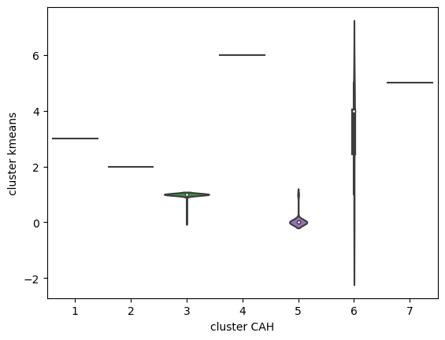

```python
# recherche de la concordance des libellés des clusters CAH vs kmeans
sns.violinplot(x="cluster CAH", y="cluster kmeans", data=df_final[["cluster CAH","cluster kmeans"]])
plt.show()
```

```python
pd.crosstab(clusters_CAH, clusters_km, margins=True)
```

| col_0 row_0 | 0 | 1 | 2 | 3 | 4 | 5 | 6 | All |
| --- | --- | --- | --- | --- | --- | --- | --- | --- |
| 1 | 0 | 0 | 0 | 2 | 0 | 0 | 0 | 2 |
| 2 | 0 | 0 | 1 | 0 | 0 | 0 | 0 | 1 |
| 3 | 1 | 92 | 0 | 0 | 0 | 0 | 0 | 93 |
| 4 | 0 | 0 | 0 | 0 | 0 | 0 | 1 | 1 |
| 5 | 64 | 4 | 0 | 0 | 0 | 0 | 0 | 68 |
| 6 | 2 | 1 | 0 | 0 | 7 | 1 | 0 | 11 |
| 7 | 0 | 0 | 0 | 0 | 0 | 2 | 0 | 2 |
| All | 67 | 97 | 1 | 2 | 7 | 3 | 1 | 178 |

```python
# on attribue les mêmes numéros de cluster CAH et Kmeans
for element in zip([3,2,1,6,0,4,5], [1,2,3,4,5,6,7]) :
    df_final.loc[df_final['cluster kmeans'] == element[0], 'cluster kmeans new'] = element[1]
```

```python
#conversion des données kmeans new en entier
df_final["cluster kmeans new"] = df_final["cluster kmeans new"].astype(int)
```

## 3.7 Liste des pays par cluster

On constate que les indivisus composants les clusters par méthode CAH ou par méthode Kmeans sont quasiment les mêmes

```python
for value in [1,2,3,4,5,6,7] :
    print(f'Liste des pays cluster {value} par méthode CAH : ')
    print(df_final[df_final["cluster CAH"] == value].index)
    print(f'Liste des pays cluster {value} par méthode Kmeans : ')
    print(df_final[df_final["cluster kmeans new"] == value].index)
    print(" ")
```

```
Liste des pays cluster 1 par méthode CAH :
Index(['Brazil', 'United States of America'], dtype='object', name='Area')
Liste des pays cluster 1 par méthode Kmeans :
Index(['Brazil', 'United States of America'], dtype='object', name='Area')

Liste des pays cluster 2 par méthode CAH :
Index(['China'], dtype='object', name='Area')
Liste des pays cluster 2 par méthode Kmeans :
Index(['China'], dtype='object', name='Area')

Liste des pays cluster 3 par méthode CAH :
Index(['Afghanistan', 'Albania', 'Algeria', 'Angola', 'Armenia', 'Azerbaijan',
       'Bangladesh', 'Benin', 'Bosnia and Herzegovina', 'Botswana',
       'Burkina Faso', 'Burundi', 'Cabo Verde', 'Cambodia', 'Cameroon',
       'Central African Republic', 'Chad', 'Colombia', 'Comoros', 'Congo',
       'Côte d'Ivoire', 'Democratic People's Republic of Korea',
       'Democratic Republic of the Congo', 'Djibouti', 'Ecuador',
       'El Salvador', 'Eswatini', 'Ethiopia', 'Gambia', 'Georgia', 'Ghana',
       'Guatemala', 'Guinea', 'Guinea-Bissau', 'Haiti', 'Honduras',
       'Indonesia', 'Iran (Islamic Republic of)', 'Jordan', 'Kenya',
       'Kiribati', 'Kyrgyzstan', 'Lao People's Democratic Republic', 'Lebanon',
       'Lesotho', 'Liberia', 'Libya', 'Madagascar', 'Malawi', 'Maldives',
       'Mali', 'Mauritania', 'Mongolia', 'Montenegro', 'Morocco', 'Mozambique',
       'Myanmar', 'Namibia', 'Nepal', 'Nicaragua', 'Niger', 'Nigeria',
       'North Macedonia', 'Pakistan', 'Papua New Guinea', 'Paraguay',
       'Philippines', 'Republic of Moldova', 'Rwanda', 'Sao Tome and Principe',
       'Senegal', 'Serbia', 'Sierra Leone', 'Solomon Islands', 'Sri Lanka',
       'Sudan', 'Syrian Arab Republic', 'Tajikistan', 'Timor-Leste', 'Togo',
       'Tunisia', 'Turkmenistan', 'Uganda', 'Ukraine',
       'United Republic of Tanzania', 'Uruguay', 'Uzbekistan', 'Vanuatu',
       'Venezuela (Bolivarian Republic of)', 'Viet Nam', 'Yemen', 'Zambia',
       'Zimbabwe'],
      dtype='object', name='Area')
Liste des pays cluster 3 par méthode Kmeans :
Index(['Afghanistan', 'Albania', 'Algeria', 'Angola', 'Armenia', 'Azerbaijan',
       'Bangladesh', 'Benin', 'Bosnia and Herzegovina', 'Botswana',
       'Burkina Faso', 'Burundi', 'Cabo Verde', 'Cambodia', 'Cameroon',
       'Central African Republic', 'Chad', 'Colombia', 'Comoros', 'Congo',
       'Côte d'Ivoire', 'Democratic People's Republic of Korea',
       'Democratic Republic of the Congo', 'Djibouti', 'Ecuador', 'Egypt',
```

[output cut: 54 more lines]

```

Liste des pays cluster 6 par méthode CAH :
Index(['Belgium', 'Cuba', 'Egypt', 'France', 'Germany', 'Japan', 'Mexico',
       'Netherlands', 'Saudi Arabia', 'South Africa',
       'United Kingdom of Great Britain and Northern Ireland'],
      dtype='object', name='Area')
Liste des pays cluster 6 par méthode Kmeans :
Index(['France', 'Germany', 'Japan', 'Mexico', 'Netherlands', 'South Africa',
       'United Kingdom of Great Britain and Northern Ireland'],
      dtype='object', name='Area')

Liste des pays cluster 7 par méthode CAH :
Index(['China, Hong Kong SAR', 'Iraq'], dtype='object', name='Area')
Liste des pays cluster 7 par méthode Kmeans :
Index(['China, Hong Kong SAR', 'Iraq', 'Saudi Arabia'], dtype='object', name='Area')
```

## 3.8 Représentation des clusters sur la carte

On utilise le geodataframe geopandas

```python
world = geopandas.read_file(geopandas.datasets.get_path('naturalearth_lowres'))

#antarctique enlevée de la carte pour esthétique :
world.drop(index=159, inplace=True)
```

```python
world.shape
# 176 pays vs 178 dans notre df_final
```

```
(176, 6)
```

```python
#certains intitulés de pays / zones ne concordent pas
set(df_final.index) - set(world["name"])
```

```
{'Antigua and Barbuda',
 'Barbados',
 'Bolivia (Plurinational State of)',
 'Bosnia and Herzegovina',
 'Cabo Verde',
 'Central African Republic',
 'China, Hong Kong SAR',
 'China, Macao SAR',
 'China, Taiwan Province of',
 'Comoros',
 "Democratic People's Republic of Korea",
 'Democratic Republic of the Congo',
 'Dominica',
 'Dominican Republic',
 'Eswatini',
 'French Polynesia',
 'Grenada',
 'Iran (Islamic Republic of)',
 'Kiribati',
 "Lao People's Democratic Republic",
 'Maldives',
 'Malta',
 'Mauritius',
 'North Macedonia',
 'Republic of Korea',
 'Republic of Moldova',
 'Russian Federation',
 'Saint Kitts and Nevis',
 'Saint Lucia',
 'Saint Vincent and the Grenadines',
 'Samoa',
 'Sao Tome and Principe',
 'Seychelles',
 'Solomon Islands',
 'Syrian Arab Republic',
 'United Kingdom of Great Britain and Northern Ireland',
 'United Republic of Tanzania',
 'Venezuela (Bolivarian Republic of)',
 'Viet Nam'}
```

certains intitulés de pays diffèrent entre le geodataframe et le df_final : - utilisation des codes ISO pour fusion des deux dataframe - recuperation des codes iso a3 https://www.fao.org/nocs/en

```python
# df assurant la concordance nom du pays - code iso A3
isoa3 = pd.read_csv("iso_a3_codes.csv", sep = ";", index_col="NAME")
isoa3.head()
```

| NAME | ISO3 |
| --- | --- |
| Afghanistan | AFG |
| Åland Islands | ALA |
| Albania | ALB |
| Algeria | DZA |
| American Samoa | ASM |

```python
#jointure gauche entre le df_final et les codes iso A3
df_final = df_final.join(isoa3)
df_final.rename(columns={"ISO3": "iso_a3"}, inplace= True)
```

```python
df_final[df_final["iso_a3"].isnull()]
# le code de Taiwan n'a pas été trouvé
```

| Area | Domestic supply quantity Poultry Meat (tonnes) 2019 | Export Quantity Poultry Meat (tonnes) 2019 | Food supply (kcal/capita/day) Poultry Meat 2019 | Import Quantity Poultry Meat (tonnes) 2019 | Production Poultry Meat (tonnes) 2019 | Total Population - Both sexes Population 2019 | Import share evolution 17-2019 | Export share evolution 17-2019 | Gross dosmestic product per capita 2019 | Political stability and absence of violence 2019 | cluster CAH | cluster kmeans | cluster kmeans new | iso_a3 |
| --- | --- | --- | --- | --- | --- | --- | --- | --- | --- | --- | --- | --- | --- | --- |
| China, Taiwan Province of | 922000.0 | 5000.0 | 146.0 | 215000.0 | 731000.0 | 23774000.0 | 0.003069 | -0.000163 | 0.0 | 0.72 | 5 | 0 | 5 | NaN |

```python
#il est défini manuellement
df_final["iso_a3"].fillna("TWN", inplace= True)
```

```python
#pays dont les codes sont présents dans le df_final mais pas dans le geodataframe
codes_not_found = set(df_final["iso_a3"]) - set(world["iso_a3"])
df_final[df_final["iso_a3"].isin(list(codes_not_found))].index
```

```
Index(['Antigua and Barbuda', 'Barbados', 'Cabo Verde', 'China, Hong Kong SAR',
       'China, Macao SAR', 'Comoros', 'Dominica', 'France', 'French Polynesia',
       'Grenada', 'Kiribati', 'Maldives', 'Malta', 'Mauritius', 'Norway',
       'Saint Kitts and Nevis', 'Saint Lucia',
       'Saint Vincent and the Grenadines', 'Samoa', 'Sao Tome and Principe',
       'Seychelles'],
      dtype='object', name='Area')
```

```python
#pays dont les codes sont présents dans le geodataframe mais pas dans le df_final
world[world["iso_a3"].isin(list(set(world["iso_a3"]) - set(df_final["iso_a3"]) ))]['name']
```

```
2                   W. Sahara
12                    Somalia
20               Falkland Is.
21                     Norway
22                  Greenland
23     Fr. S. Antarctic Lands
43                     France
45                Puerto Rico
69                 Eq. Guinea
79                  Palestine
84       United Arab Emirates
85                      Qatar
100                    Bhutan
149                    Brunei
154                   Eritrea
160                 N. Cyprus
167                Somaliland
174                    Kosovo
176                  S. Sudan
Name: name, dtype: object
```

```python
# 5 pays ont un code ISO A3 erroné dans le geodataframe
world[world["iso_a3"] == "-99"]
```

|  | pop_est | continent | name | iso_a3 | gdp_md_est | geometry |
| --- | --- | --- | --- | --- | --- | --- |
| 21 | 5320045 | Europe | Norway | -99 | 364700.0 | MULTIPOLYGON (((15.14282 79.67431, 15.52255 80... |
| 43 | 67106161 | Europe | France | -99 | 2699000.0 | MULTIPOLYGON (((-51.65780 4.15623, -52.24934 3... |
| 160 | 265100 | Asia | N. Cyprus | -99 | 3600.0 | POLYGON ((32.73178 35.14003, 32.80247 35.14550... |
| 167 | 3500000 | Africa | Somaliland | -99 | 12250.0 | POLYGON ((48.94820 11.41062, 48.94820 11.41062... |
| 174 | 1895250 | Europe | Kosovo | -99 | 18490.0 | POLYGON ((20.59025 41.85541, 20.52295 42.21787... |

```python
# on défini manuellement les codes ISO A3 existants
for element in zip(["France", "Norway"], ["FRA", "NOR"]) :
    world.loc[world['name'] == element[0], 'iso_a3'] = element[1]
```

```python
#nous ne disposons pas des données pour les pays/territoires ci dessous, qui sont donc écartés pour la représentation
world[world["iso_a3"].isin(list(set(world["iso_a3"]) - set(df_final["iso_a3"])))]['name']
```

```
2                   W. Sahara
12                    Somalia
20               Falkland Is.
22                  Greenland
23     Fr. S. Antarctic Lands
45                Puerto Rico
69                 Eq. Guinea
79                  Palestine
84       United Arab Emirates
85                      Qatar
100                    Bhutan
149                    Brunei
154                   Eritrea
160                 N. Cyprus
167                Somaliland
174                    Kosovo
176                  S. Sudan
Name: name, dtype: object
```

```python
#projection sur les colonnes à fusionner dans le geodataframe world
clusters_col = df_final[["cluster CAH", "cluster kmeans new", "iso_a3"]]
```

```python
#fusion du df clusters avec le geodataframe world pour affichage des clusters
world = world.merge(clusters_col, how = "left", on = "iso_a3")
```

```python
#on vérifie la présence de nulls après fusion :
world.info()
# comme vu précédemment, nous ne possédons pas les données pour 17 territoires du geodatagrame, d'où les 17 valeurs nulles
```

```
<class 'geopandas.geodataframe.GeoDataFrame'>
Int64Index: 176 entries, 0 to 175
Data columns (total 8 columns):
 #   Column              Non-Null Count  Dtype
---  ------              --------------  -----
 0   pop_est             176 non-null    int64
 1   continent           176 non-null    object
 2   name                176 non-null    object
 3   iso_a3              176 non-null    object
 4   gdp_md_est          176 non-null    float64
 5   geometry            176 non-null    geometry
 6   cluster CAH         159 non-null    float64
 7   cluster kmeans new  159 non-null    float64
dtypes: float64(3), geometry(1), int64(1), object(3)
memory usage: 12.4+ KB
```

```python
# griser les pays n'ayant pas de cluster
world.drop(labels = world[world["cluster CAH"].isnull()].index, inplace=True)
```

```python
#modification du type de données pour les variables cluster
world["cluster CAH"] = world["cluster CAH"].astype(int).astype(str)
world["cluster kmeans new"] = world["cluster kmeans new"].astype(int).astype(str)
```

```
Clustering issu de la classification ascendante hiérarchique
```

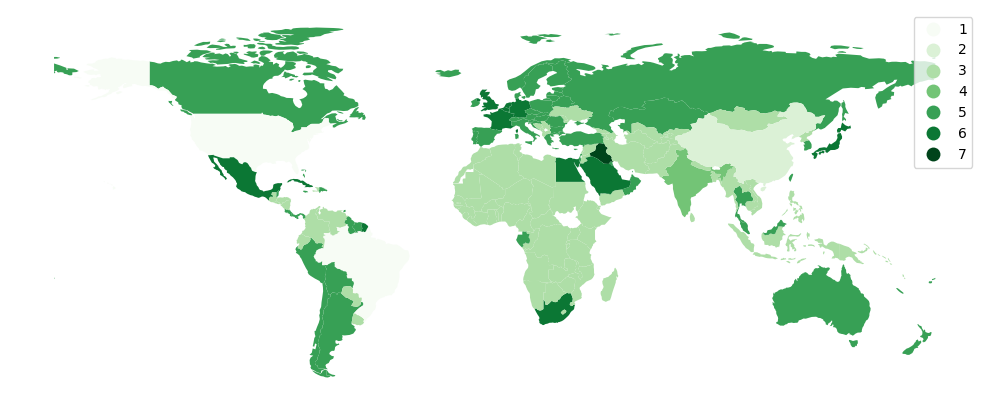

```
Clustering issu du Kmeans
```

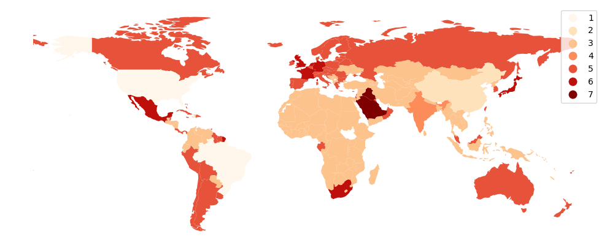

```python
print("Clustering issu de la classification ascendante hiérarchique")
world.plot(column='cluster CAH', cmap='Greens', figsize=(20, 5),legend = [1,2,3,4,5]).axis('off')
plt.show()
print("Clustering issu du Kmeans")
world.plot(column='cluster kmeans new', figsize=(20, 5), cmap='OrRd', legend = [1,2,3,4,5]).axis('off')
plt.show()
```

Le clustering nous permet de retrouver certains grands acteurs que nous avions auparavant identifiés :

- 1 le Brésil et les Etats Unis, géants de la production et de l'exportation
- 2 la Chine, géant de la production et de l'importation
- 4 L'Inde, géant de la production

Les autres clusters comportent de multiples pays : afin de comprendre ce qui uni ces pays, nous allons réaliser une heatmap montrant les moyennes centrées réduites obtenues par cluster pour chaque variable, ainsi qu'une ACP nous permettant de visualiser les clusters sur des plans factoriels synthétisant les variables.

## 3.8 Heatmap croisement clusters et variables

```python
#calcul de la moyenne par cluster CAH et variable
means_cluster_CAH = df_final.pivot_table(index = "cluster CAH", aggfunc='mean' ).drop(columns = ["cluster kmeans", "cluster kmeans new"])
```

```python
#standardisation des valeurs
means_cluster_CAH_scaled = preprocessing.StandardScaler().fit_transform(means_cluster_CAH)
```

```python
#générer le dataframe avec les valeurs standardisées
means_cluster_CAH_scaled = pd.DataFrame(means_cluster_CAH_scaled, index = [1,2,3,4,5,6,7], columns= means_cluster_CAH.columns)
```

```python
#calcul de la moyenne par cluster Kmeans et variable
means_cluster_kmeans = df_final.pivot_table(index = "cluster kmeans new", aggfunc='mean' ).drop(columns = ["cluster kmeans", "cluster CAH"])
```

```python
#standardisation des valeurs
means_cluster_kmeans_scaled = preprocessing.StandardScaler().fit_transform(means_cluster_kmeans)
```

```python
#générer le dataframe avec les valeurs standardisées
means_cluster_kmeans_scaled = pd.DataFrame(means_cluster_kmeans_scaled, index = [1,2,3,4,5,6,7], columns= means_cluster_kmeans.columns)
```

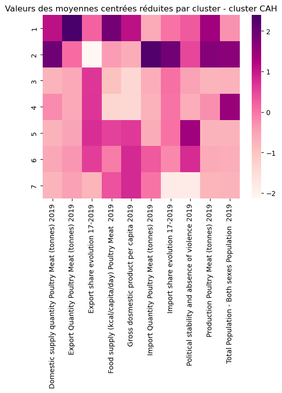

```python
MCR_clusters_CAH = plt.figure()
cmap = sns.cm.rocket_r
sns.heatmap(means_cluster_CAH_scaled, cmap ='RdPu')
plt.title("Valeurs des moyennes centrées réduites par cluster - cluster CAH")
plt.show()
```

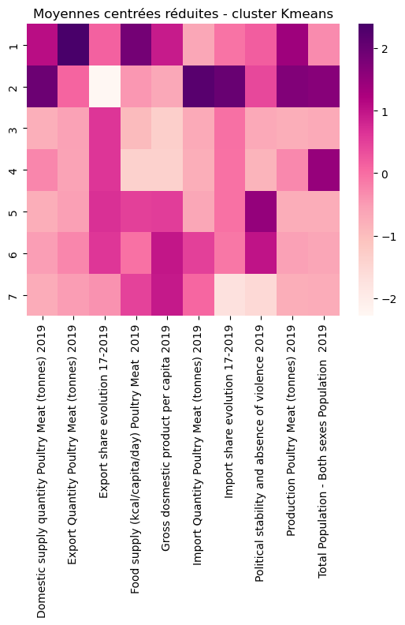

```python
# générer un masque pour la matrice des corrélations
MCR_clusters_kmeans = plt.figure()
cmap = sns.cm.rocket_r
sns.heatmap(means_cluster_kmeans_scaled, cmap ='RdPu')
plt.title("Moyennes centrées réduites - cluster Kmeans")
plt.show()
```

Les résultats sont identiques pour les clusters CAH et Kmeans :

- disponibilité intérieure (quantité) : moyennes les plus élevées sur les clusters 1 et 2 (USA, Brésil, Chine)
- production : moyennes les plus élevées sur les clusters 1 et 2 (USA, Brésil, Chine)
- export (quantité) : moyenne la plus élevée sur le cluster 1 (USA, Brésil)
- import quantity : moyenne la plus élevée sur le cluster 2 (Chine)
- population : moyennes les plus élevées sur les clusters 2 et 4 (Chine, Inde)
- export share evolution : moyennes semblables sur les cluster 3 à 6, la plus faible sur le cluster 2 (Chine)
- import share evolution : moyenne la plus élevée sur le cluster 2 (Chine) moyennes semblables sur les clusters 1,3,4,5,6 et la plus faible sur le cluster 7
- disponibilité alimentaire volaille : moyenne la plus élevée sur le cluster 1 (USA, Brésil), et moyennes les plus faibles sur les clusters 3 et 4
- PIB par habitant : moyennes les plus faibles sur les clusters 4 (Inde) et 3, les plus élevées sur les clusters 1 (USA, Brésil),6,7
- political stability : moyennes les plus élevées sur le cluster 5,6 et la plus faible sur le cluster 7